# Hyperwar Analysis

Ryan Heslin May 27, 2022

Today I’ll tidy some data from [Hyperwar](https://www.ibiblio.org/hyperwar/AAF/StatDigest/aafsd-3.html), an archive of World War II primary source documents. The data are several tables of aircraft in Army Air Forces service each month of the war, broken down by role and type. Challenges include nested headers, blank rows, and several nasty OCR errors.

```r
library(tidyverse)
library(rlang)
library(rvest)
library(lubridate)

url <- "https://www.ibiblio.org/hyperwar/AAF/StatDigest/aafsd-3.html"

sel <- "blockquote:nth-child(113) table , blockquote:nth-child(109) table, blockquote:nth-child(105) table, blockquote:nth-child(101) table"
```

Scraping is not too challenging.

```r
raw <- read_html(url) %>%
  html_elements(css = sel) %>%
  html_table()
```

After some experimentation, I devise a function to clean the data.

```r
clean_hyperwar <- function(tab) {
  tab <- tab[, colSums(is.na(tab)) != nrow(tab)]
  names(tab) <- c("Type", paste(tab[1, -1], names(tab)[-1]))
  tab %>%
    mutate(
      Category = str_extract(Type, "(^[^0-9\\-]+)(?=s--)"),
      .before = Category
    ) %>%
    fill(Category, .direction = "down") %>%
    mutate(
      Type = case_when(
        str_detect(Type, "2nd") ~ paste("2nd. Line", Category),
        str_detect(Type, "^Other") ~ paste("Other", Category),
        TRUE ~ Type
      )
    ) %>%
    mutate(
      across(
        -c(Type, Category),
        ~ str_replace_all(
          .x,
          c(
            "-" = "0", "(\\d+,\\d{3})\\d" = "\\1",
            "," = ""
          )
        ) %>%
          as.numeric()
      )
    ) %>%
    filter(
      if_all(-c(Type, Category), ~ !is.na(.x)) &
        !str_detect(Type, "Total|1st|^Combat Airplanes$")
    ) %>%
    pivot_longer(
      cols = -c(Type, Category),
      names_to = "Month-Year",
      values_to = "Number"
    ) %>%
    mutate(across(
      c(Type, Category),
      as.factor
    ))
}
```

Data in hand, I fill in missing combinations and recode an OCR glitch.

```r
cleaned <- map(raw, clean_hyperwar) %>%
  bind_rows() %>%
  mutate(
    `Month-Year` = my(`Month-Year`),
    Number = recode(Number, `7221` = 721)
  ) %>%
  complete(nesting(Category, Type), `Month-Year`, fill = list(Number = 0))
```

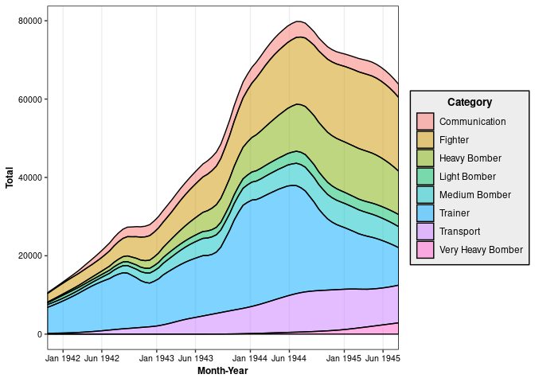

```r
my_theme()

breaks <- paste(rep(c("Jan", "Jun"), times = 4), rep(1941:1945, 2))

cleaned %>%
  group_by(`Month-Year`, Category) %>%
  summarize(Total = sum(Number)) %>%
  ggplot(aes(x = `Month-Year`, y = Total, fill = Category)) +
  stat_smooth(
    geom = "area", method = "loess", position = position_stack(),
    outline.type = "full",
    color = "black", alpha = .5, bandwith = .2, span = .2
  ) +
  scale_x_date(breaks = my(breaks), labels = breaks, expand = c(0, 0))
```

After filtering out trainers, the rising share of fighters is evidence of the intensifying campaign for air superiority.

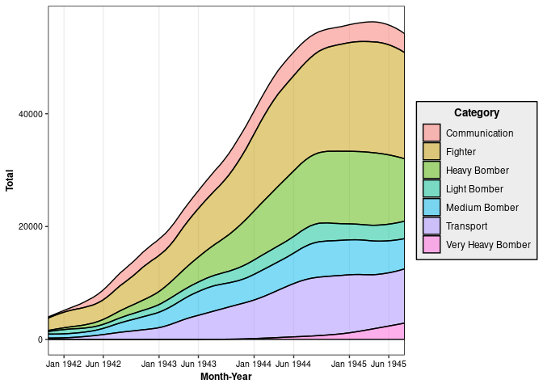

```r
cleaned %>%
  filter(Category != "Trainer") %>%
  group_by(`Month-Year`, Category) %>%
  summarize(Total = sum(Number)) %>%
  ggplot(aes(x = `Month-Year`, y = Total, fill = Category)) +
  stat_smooth(
    geom = "area", method = "loess",
    position = position_stack(),
    outline.type = "full", color = "black", alpha = .5,
    bandwith = .2, span = .2
  ) +
  scale_x_date(breaks = my(breaks), labels = breaks, expand = c(0, 0))
```

I plot the top three types on hand each month. These plots reveal a shift from fighters to heavy bombers and transports midway through the war. There were initially some odd spikes I fixed by correcting OCR errors.

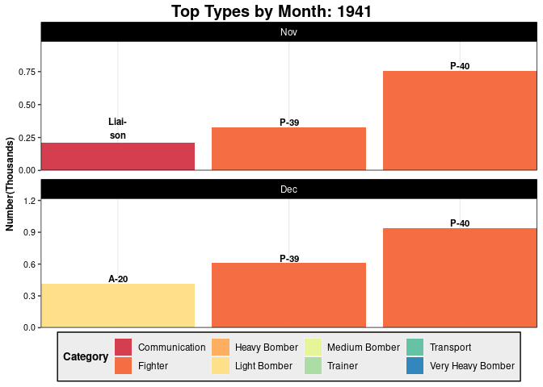

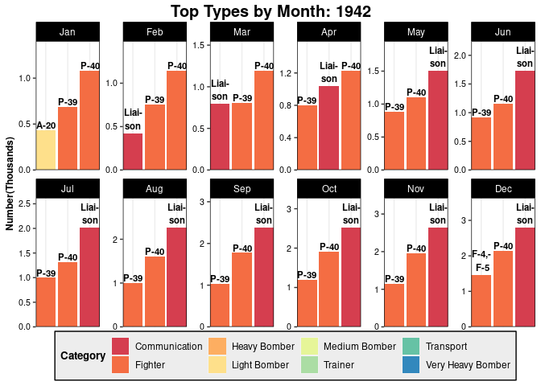

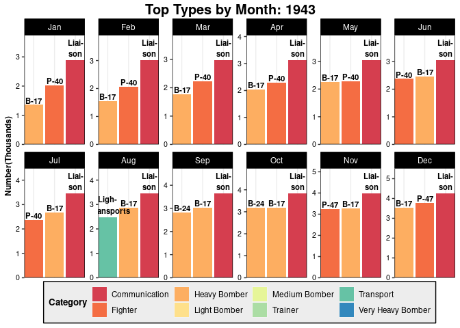

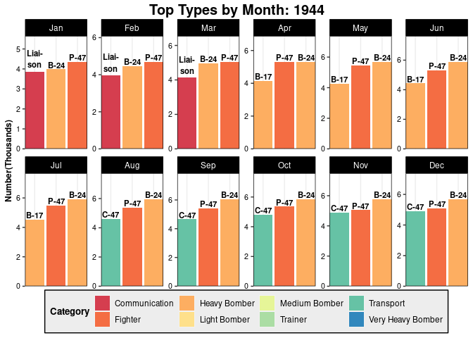

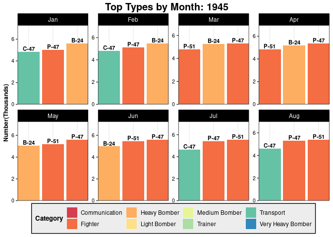

```r
top_types <- cleaned %>%
  group_by(`Month-Year`) %>%
  filter(Category != "Trainer" & !str_detect(Type, "2nd|Other")) %>%
  slice_max(n = 3, order_by = Number) %>%
  mutate(Type_ordered = tidytext::reorder_within(Type, Number, within = `Month-Year`)) %>%
  ungroup() %>%
  arrange(`Month-Year`) %>%
  mutate(
    Year = year(`Month-Year`), Month = month(`Month-Year`, label = TRUE),
    Type = fct_recode(Type, "C-47" = "C-47, C-53")
  )

pal <- RColorBrewer::brewer.pal(n = nlevels(top_types$Category), name = "Spectral") %>%
  setNames(levels(top_types$Category))
plots <- top_types %>%
  group_by(Year) %>%
  group_map(
    ~ ggplot(
      data = .x,
      aes(
        x = Type_ordered,
        label = str_replace(Type, "(.{4})(.+)", "\\1-\n\\2"),
        y = Number / 1000,
        fill = Category
      )
    ) +
      geom_col(position = "dodge") +
      geom_text(
        size = 3,
        vjust = -.2,
        fontface = "bold"
      ) +
      scale_fill_manual(values = pal) +
      tidytext::scale_x_reordered(expand = c(0, 0)) +
      facet_wrap(. ~ Month, nrow = 2, scales = "free") +
      scale_y_continuous(expand = expansion(mult = c(0, .3))) +
      labs(
        title = paste("Top Types by Month:", .y),
        x = NULL,
        y = "Number(Thousands)"
      ) +
      theme(
        legend.position = "bottom",
        legend.box.spacing = unit(0.05, "cm"),
        axis.text.x = element_blank(),
        axis.ticks.x = element_blank(),
      )
  )

walk(plots, print)
```

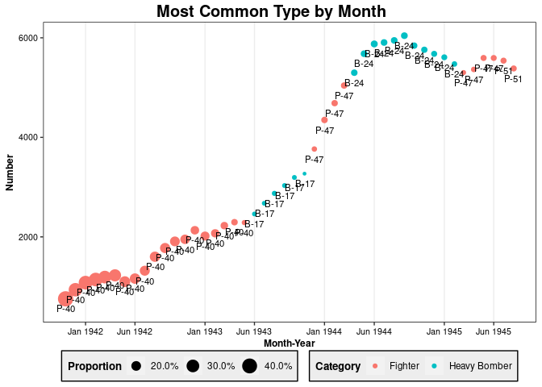

```r
cleaned %>%
  group_by(`Month-Year`) %>%
  filter(Category != "Trainer" & !str_detect(Type, "2nd|Other|Liaison")) %>%
  mutate(Proportion = Number / sum(Number)) %>%
  slice_max(n = 1, order_by = Number) %>%
  ungroup() %>%
  arrange(`Month-Year`) %>%
  mutate(
    Year = year(`Month-Year`), Month = month(`Month-Year`, label = TRUE),
    Type = fct_recode(Type, "C-47" = "C-47, C-53")
  ) %>%
  ggplot(aes(x = `Month-Year`, y = Number, color = Category, label = Type, size = Proportion)) +
  geom_point() +
  geom_text(size = 3, nudge_y = -200, color = "black", face = "bold") +
  scale_size_continuous(labels = scales::percent_format()) +
  scale_x_date(breaks = my(breaks), labels = breaks) +
  theme(
    legend.position = "bottom",
    legend.box.spacing = unit(0.05, "cm")
  ) +
  labs(title = "Most Common Type by Month")
```